# checkpoint1

## Introdução

Neste checkpoint escolhi quatro séries: Sherlock, Flash, Gotham e How to Get Away with Murder. Inicialmente, listarei suas informações: Nome, season, episódio de cada temporada e sua avaliação. Escolhi essas séries pois tem uma quantidade de temporada não varia muito.

```r
series <- all_series %>%
  filter(series_name %in% c("Gotham", "Sherlock", "Flash", "How to Get Away with Murder")) %>%
  group_by(series_name) %>%
  select(season, season_ep, UserRating)
series
```

```
## Source: local data frame [190 x 4]
## Groups: series_name [4]
##
## # A tibble: 190 x 4
##                    series_name season season_ep UserRating
##                          <chr>  <int>     <int>      <dbl>
##  1 How to Get Away with Murder      1         1        8.6
##  2 How to Get Away with Murder      1         2        8.3
##  3 How to Get Away with Murder      1         3        8.2
##  4 How to Get Away with Murder      1         4        8.7
##  5 How to Get Away with Murder      1         5        8.4
##  6 How to Get Away with Murder      1         6        8.6
##  7 How to Get Away with Murder      1         7        8.3
##  8 How to Get Away with Murder      1         8        8.6
##  9 How to Get Away with Murder      1         9        9.4
## 10 How to Get Away with Murder      1        10        8.8
## # ... with 180 more rows
```

## Comparando as séries

Para classificar qual a melhor avaliação, irei utilizar como base o UserRating, que corresponde avaliação. Inicialmente, mostrarei a avaliação de cada série individualmente, associando a temporada com a média de UserRating.

How to Get Away with Murder

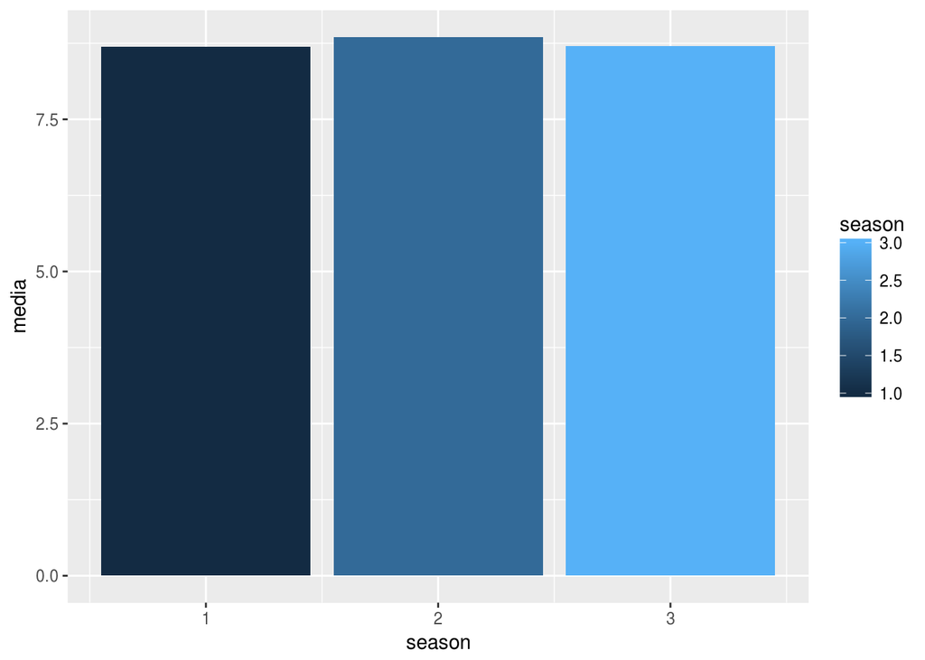

```r
media.hgmuder <- series %>%
  filter(series_name== "How to Get Away with Murder") %>%
  group_by(season) %>%
  summarise(media = mean(UserRating), mediana = median(UserRating), numobser = n())

ggplot(data = media.hgmuder, aes(x=season, y=media, fill = season)) + geom_bar(stat = "identity")
```

Gotham

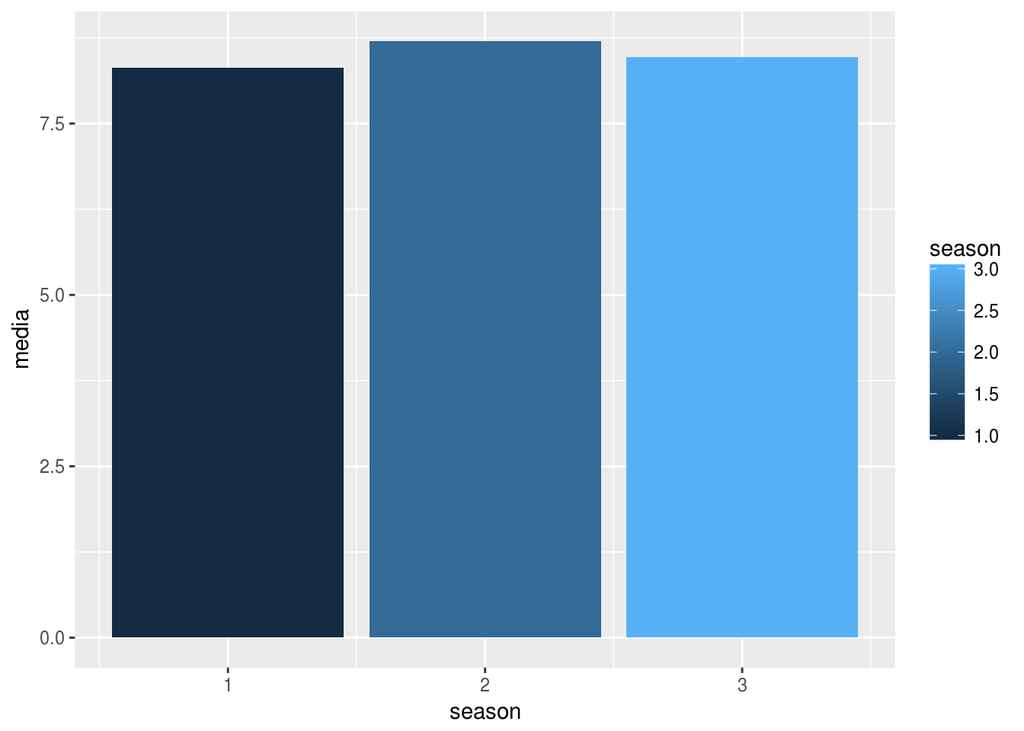

```r
media.gotham <- series %>%
  filter(series_name== "Gotham") %>%
  group_by(season) %>%
  summarise(media = mean(UserRating), mediana = median(UserRating), numobser = n())

ggplot(data = media.gotham, aes(x=season, y=media, fill = season)) + geom_bar(stat = "identity")
```

Flash

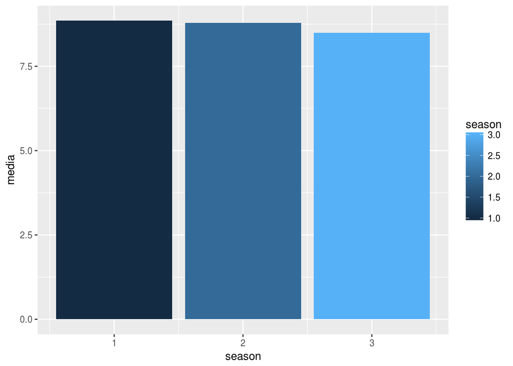

```r
media.flash <- series %>%
  filter(series_name== "Flash") %>%
  group_by(season) %>%
  summarise(media = mean(UserRating), mediana = median(UserRating), numobser = n())

ggplot(data = media.flash, aes(x=season, y=media, fill = season)) + geom_bar(stat = "identity")
```

Sherlock

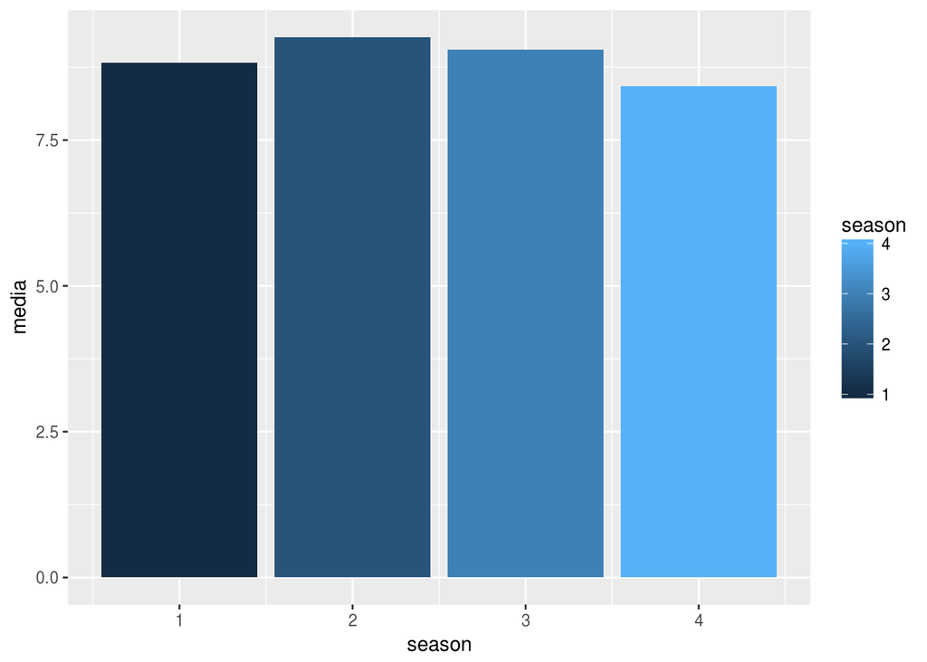

```r
media.sherlock <- series %>%
  filter(series_name== "Sherlock") %>%
  group_by(season) %>%
  summarise(media = mean(UserRating), mediana = median(UserRating), numobser = n())

ggplot(data = media.sherlock, aes(x=season, y=media, fill = season)) + geom_bar(stat = "identity")
```

Já apresentado os dados, para comparar as séries farei de acordo com a média geral de cada e assim qual é o mais bem avaliado.

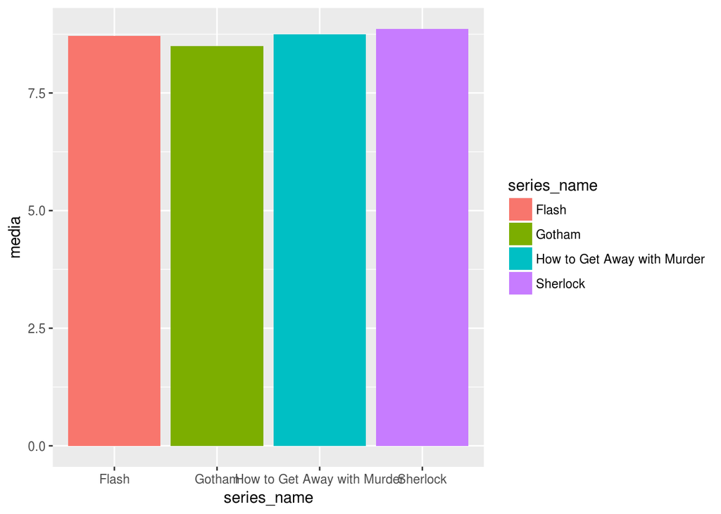

```r
media.geral <- series %>%
  group_by(series_name) %>%
  summarise(media = mean(UserRating))

ggplot(data = media.geral, aes(x=series_name, y=media, fill = series_name)) + geom_bar(stat = "identity")
```

A partir do gráfico pode-se perceber que a diferença entre as mesma não é muito grande, e que a mais bem avaliada é Sherlock, com um pequena diferença entre How to Get Away with Murder.

Para um maior aprofundamento na análise das médias de cada série, pode-se usar o boxpot.

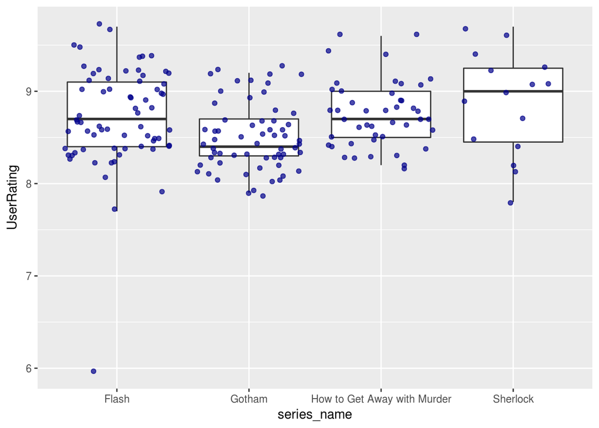

```r
medias <- series

ggplot(medias, mapping = aes(x = series_name,
                             y = UserRating)) +
  geom_boxplot(outlier.colour = NA) +
  geom_point(position = position_jitter(width = .4),
             alpha = .7,
             color = "darkblue")
```

Analisando cada série em particular temos: Flash, apresenta uma grande dispersão e pontos extremos, pode-se perceber também que os episódios aparentemente estão bem divididos. Quanto a sua qualidade não é regular, porém a diferença entre eles não é grande. Gotham, não possue pontos extremos e não estão muito dispersados, porém os dados não se repetem muito, o primeiro e o segundo quartil tem seus dados muito próximos. Apresenta uma qualidade mais regular. How to Get Away, estão com pontos dispersos e apresenta assimetria, como e acontecem em Gotham aprensenta o primeiro e o segundo quartil com dados muito próximos, com pouca variação entre sí. Sherlock, tem seus dados dispersos, sem valores muito frequentes, pode-ser ver que existe uma qualidade inregular com grande diferença entre sí.